# RQ2: What kinds of building markets does New Zealand have?

Building consents (Stats NZ, Aug 2026) — k-means and hierarchical clustering of district profiles

Andrew Boulton — while True: learn(), Group 8, STAT462

This document answers research question 2 of our project: *what kinds of building markets does New Zealand have?* It builds one profile per district from ten years of consents (2016–2025), looks at the profiles before clustering anything, and then applies the two clustering methods of Module 7 in the order the course teaches them: $k$-means, with the number of clusters chosen by the silhouette coefficient, and hierarchical clustering with complete, single and average linkage. Clustering has no test set, so the evaluation asks different questions: do the two methods agree, do the groups survive a different starting point or a different ten years, and do they tell us anything about cost — which ties this question back to RQ1. It ends with a re-run that adds cost to the inputs, so the result can be compared with Niwesh’s build.

# 1 Set up

## 1.1 Data

We start from the same district-by-quarter table as RQ1, built by Niwesh’s Step 1 notebook from the Stats NZ *Building consents by territorial authority (Monthly)* file. RQ1 used the version with the small quarters removed (`rq1_model_data.csv`); here we read the full version, because a district profile pools ten years of consents and has no use for a minimum per quarter.

```r
quarters <- read_csv(file.path(data_root, "rq1_district_quarter_full.csv"),
                     show_col_types = FALSE)

cat("Rows:", nrow(quarters), " Columns:", ncol(quarters),
    " Districts:", n_distinct(quarters$ta),
    " Quarters:", min(quarters$yq), "to", max(quarters$yq), "\n")
```

```
## Rows: 9715  Columns: 43  Districts: 67  Quarters: 1990Q2 to 2026Q2
```

9,715 rows: 67 districts by 145 quarters, 1990Q2 to 2026Q2.

## 1.2 One profile per district

Clustering needs one row per thing to be grouped. The thing is a district, and the row is a summary of how it built over a window of years. The window is 2016–2025: the ten most recent complete calendar years, long enough to smooth out a single unusual year and recent enough to describe the market as it is now. Section 5 checks what happens with a different window.

The profile has six inputs, chosen to describe *how* a district builds and all of them free of scale, so that Auckland is not set apart simply for being large:

| Input | What it measures | How it is built |
| --- | --- | --- |
| `multi_share` | How much of the new housing is not stand-alone houses | 1 − new houses ÷ new dwellings |
| `retire_share` | How much is retirement-village units | retirement units ÷ new dwellings |
| `house_m2` | How big the new houses are | floor area of new houses ÷ number of new houses |
| `per1000` | How fast the district is building for its size | new dwellings per 1,000 residents per year, averaged over the window |
| `growth` | Whether building sped up or slowed down within the window | log of dwellings per year in the later half ÷ the earlier half |
| `alt_share` | How much residential work is on existing homes | alterations $ ÷ (alterations $ + new residential $), real dollars |

```r
# one row per district for the years first_year to last_year
build_profile <- function(first_year, last_year) {
  mid_year <- (first_year + last_year) %/% 2

  window <- quarters %>%
    dplyr::filter(year >= first_year, year <= last_year) %>%
    # put every dollar figure into June-2026 dollars before adding quarters up
    mutate(alt_real    = resid_alt_val * real_factor,
           new_real    = resid_new_val * real_factor,
           houses_real = houses_val * real_factor)

  # the national cost per m2 over the same window, for the relative cost
  nz_cost_m2 <- sum(window$houses_real) / sum(window$houses_m2)

  window %>%
    group_by(ta, region) %>%
    summarise(
      dwellings    = sum(dwell_n),
      multi_share  = 1 - sum(houses_n) / sum(dwell_n),
      retire_share = sum(retire_n) / sum(dwell_n),
      house_m2     = sum(houses_m2) / sum(houses_n),
      # dwell_per_1000 is a rolling 12-month rate, so its December-quarter value is the calendar year
      per1000      = mean(dwell_per_1000[quarter == 4]),
      early        = sum(dwell_n[year <= mid_year]) / n_distinct(year[year <= mid_year]),
      late         = sum(dwell_n[year >  mid_year]) / n_distinct(year[year >  mid_year]),
      alt_share    = sum(alt_real) / (sum(alt_real) + sum(new_real)),
      # not a clustering input: kept to ask afterwards whether the groups differ in cost
      rel_cost     = log((sum(houses_real) / sum(houses_m2)) / nz_cost_m2),
      .groups = "drop") %>%
    mutate(growth = log((late + 1) / (early + 1)),
           # short names for plots: "Selwyn District" -> "Selwyn"
           district = str_remove(ta, " District$| City$| Territory$")) %>%
    dplyr::select(district, ta, region, dwellings, multi_share, retire_share,
                  house_m2, per1000, growth, alt_share, rel_cost)
}

profile <- build_profile(2016, 2025)

# the short names label every plot, so they have to be unique
stopifnot(!anyDuplicated(profile$district), !anyNA(profile))
dim(profile)
```

```
## [1] 67 11
```

67 rows, one per district. The six inputs go into a plain data frame with the district name as the row name, which is what `kmeans()`, `dist()` and the dendrograms will pick up as labels.

```r
inputs <- c("multi_share", "retire_share", "house_m2", "per1000", "growth", "alt_share")

dat <- as.data.frame(profile[, inputs])
rownames(dat) <- profile$district

summary(dat)
```

```
##   multi_share       retire_share        house_m2        per1000
##  Min.   :0.04357   Min.   :0.00000   Min.   :126.8   Min.   : 1.230
##  1st Qu.:0.12645   1st Qu.:0.01179   1st Qu.:175.1   1st Qu.: 3.615
##  Median :0.17223   Median :0.03913   Median :185.3   Median : 5.060
##  Mean   :0.22895   Mean   :0.05182   Mean   :182.3   Mean   : 6.270
##  3rd Qu.:0.31397   3rd Qu.:0.08556   3rd Qu.:194.3   3rd Qu.: 7.805
##  Max.   :0.73034   Max.   :0.19326   Max.   :210.9   Max.   :27.630
##      growth           alt_share
##  Min.   :-0.86904   Min.   :0.03549
##  1st Qu.:-0.03229   1st Qu.:0.11625
##  Median : 0.15719   Median :0.17412
##  Mean   : 0.14793   Mean   :0.17350
##  3rd Qu.: 0.31046   3rd Qu.:0.21188
##  Max.   : 1.01149   Max.   :0.32747
```

**What was left out, and why.** *Cost per m²* (`rel_cost`) is built but deliberately kept out of the inputs: RQ1 is about cost, and if cost helps form the groups then “do the groups differ in cost?” has only one possible answer. Leaving it out makes that a real question (section 5.3); section 5.4 puts it back in for the comparison with Niwesh. *District size* (number of dwellings) is left out so that the groups describe a kind of market, not a size of council. *Townhouse and apartment shares* are parts of `multi_share` (correlation 0.90 and 0.70 with it) and would count the same thing three times. *Volatility* of yearly consents was tried and dropped: it is mostly a measure of how small a district is (correlation −0.60 with log dwellings).

**Chatham Islands.** The Chatham Islands consented 34 new dwellings in the ten years, so every share in its profile rests on a handful of buildings. It is kept, because the question is about all 67 districts, but expect it to behave as an outlier and read its row with that in mind.

# 2 First impression

Before clustering: what does each input look like, how do the inputs relate to each other, and can groups be seen by eye?

## 2.1 The six inputs

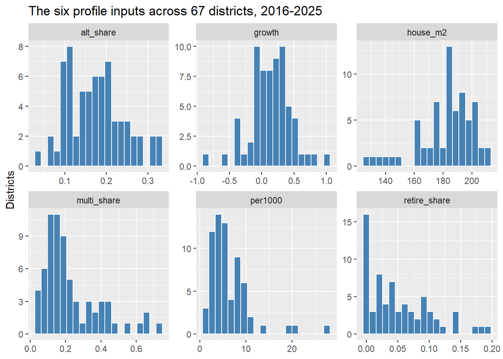

```r
dat %>%
  pivot_longer(everything(), names_to = "input", values_to = "x") %>%
  ggplot(aes(x = x)) +
  geom_histogram(bins = 20, fill = "steelblue", colour = "white") +
  facet_wrap(~ input, scales = "free", ncol = 3) +
  labs(title = "The six profile inputs across 67 districts, 2016-2025",
       x = NULL, y = "Districts")
```

None of the six divides the districts into two clear humps, which is the first hint about what clustering will find: a district is not obviously one type or another on any single measure. `per1000` and `multi_share` have long right tails — a few districts build far faster, or far more densely, than the rest — and the tails are where the names everyone would guess sit:

```r
# the three highest and three lowest districts on each input
extremes <- function(v) {
  o <- order(dat[[v]])
  tibble(input   = v,
         lowest  = paste0(rownames(dat)[head(o, 3)], " (", signif(dat[[v]][head(o, 3)], 2), ")",
                          collapse = ", "),
         highest = paste0(rownames(dat)[rev(tail(o, 3))], " (", signif(dat[[v]][rev(tail(o, 3))], 2), ")",
                          collapse = ", "))
}

map_dfr(inputs, extremes) %>%
  knitr::kable(caption = "The three lowest and three highest districts on each input")
```

The three lowest and three highest districts on each input

| input | lowest | highest |
| --- | --- | --- |
| multi_share | Kaipara (0.044), Waimate (0.046), Otorohanga (0.055) | Wellington (0.73), Lower Hutt (0.67), Hamilton (0.65) |
| retire_share | Buller (0), Central Hawke’s Bay (0), Chatham Islands (0) | Horowhenua (0.19), Nelson (0.19), Napier (0.18) |
| house_m2 | Chatham Islands (130), Buller (130), Kawerau (130) | Auckland (210), Manawatu (210), Queenstown-Lakes (210) |
| per1000 | Kawerau (1.2), Wairoa (1.7), Tararua (1.8) | Queenstown-Lakes (28), Selwyn (21), Mackenzie (19) |
| growth | Chatham Islands (-0.87), Tauranga (-0.53), Wellington (-0.4) | Rotorua (1), Buller (0.85), Wairoa (0.71) |
| alt_share | Selwyn (0.035), Waimakariri (0.061), Hamilton (0.068) | Kawerau (0.33), Wairoa (0.32), Wellington (0.31) |

Queenstown-Lakes builds 27.6 dwellings a year per 1,000 residents, more than five times the median district’s 5.1; Selwyn and Mackenzie are next. Wellington City, Lower Hutt and Hamilton are about two-thirds multi-unit. Kawerau, Wairoa and Wellington City spend the largest share of their residential dollars on existing homes.

## 2.2 How the inputs relate

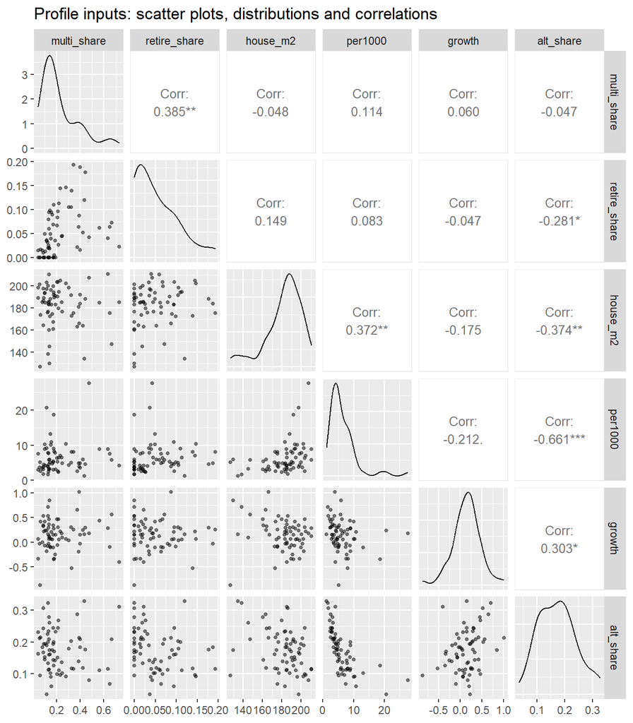

```r
ggpairs(dat,
        lower = list(continuous = wrap("points", alpha = 0.5, size = 1)),
        upper = list(continuous = wrap("cor", size = 3.5))) +
  labs(title = "Profile inputs: scatter plots, distributions and correlations")
```

One strong relationship stands out: `per1000` and `alt_share` are correlated at −0.66. Districts that build a lot for their size spend little of their residential money on alterations, and the reverse — a single axis that runs from “building new” to “looking after what is there”. `house_m2` leans the same way (0.37 with `per1000`, −0.37 with `alt_share`): the fast builders build bigger houses. The two mix measures, `multi_share` and `retire_share`, are related to each other (0.39) and to almost nothing else. So the six inputs carry roughly two separate ideas: how much new building there is, and what form it takes.

## 2.3 Can groups be seen by eye?

One input from each idea gives the two-variable picture used through the rest of the document.

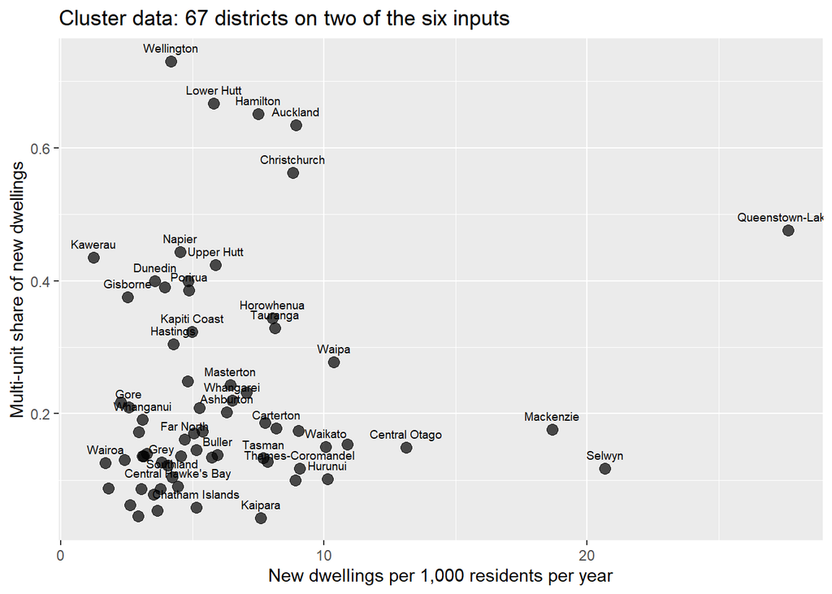

```r
ggplot(dat, aes(x = per1000, y = multi_share)) +
  geom_point(size = 3, alpha = 0.7) +
  geom_text(aes(label = rownames(dat)), size = 2.5, vjust = -1, check_overlap = TRUE) +
  labs(title = "Cluster data: 67 districts on two of the six inputs",
       x = "New dwellings per 1,000 residents per year",
       y = "Multi-unit share of new dwellings")
```

There are no gaps. The districts form one cloud that thins out towards two corners: up, towards the dense cities, and right, towards Queenstown-Lakes, Selwyn and Mackenzie. Whatever clustering returns will be a way of cutting that cloud, and the evaluation in section 5 has to ask how much the cut depends on where we happened to make it.

# 3 k-means clustering

$k$-means places $k$ centres and assigns every district to its nearest one, moving the centres until the total squared distance from districts to their centres stops falling. It needs three decisions from us: whether to scale the inputs, how many times to start it, and the value of $k$.

## 3.1 Scaling

```r
round(apply(dat, 2, var), 4)
```

```
##  multi_share retire_share     house_m2      per1000       growth    alt_share
##       0.0265       0.0026     356.7284      19.4042       0.0998       0.0045
```

The inputs are on wildly different scales: house size, in square metres, has a variance of 357, while the shares have variances below 0.03. $k$-means works on distances, so unscaled it would see almost nothing but house size. We can check that it does:

```r
set.seed(462)
k.unscaled <- kmeans(dat, 3, nstart = 50)

# the range of house sizes inside each unscaled cluster
tapply(dat$house_m2, k.unscaled$cluster, range) %>%
  sapply(function(r) paste(round(r), collapse = " to "))
```

```
##            1            2            3
## "127 to 147" "160 to 186" "188 to 211"
```

The three unscaled clusters are three bands of house size that do not overlap — small, medium and large houses, with the other five inputs ignored. Standardising each input to mean 0 and standard deviation 1 gives all six an equal say.

```r
scaled_dat <- scale(dat)

round(apply(scaled_dat, 2, sd), 2)
```

```
##  multi_share retire_share     house_m2      per1000       growth    alt_share
##            1            1            1            1            1            1
```

## 3.2 The starting point

`kmeans()` starts from $k$ randomly chosen districts, and where it ends up can depend on where it starts. To see how much, we run it thirty times from a single random start each, with $k = 3$, and record the total within-cluster sum of squares it reaches (lower is better).

```r
# thirty runs, one random start each
single_start <- sapply(1:30, function(s) {
  set.seed(s)
  kmeans(scaled_dat, 3, nstart = 1)$tot.withinss
})

cat("Different answers in 30 single-start runs:", n_distinct(round(single_start, 4)), "\n")
```

```
## Different answers in 30 single-start runs: 14
```

```r
cat("Runs that reached the best answer found:  ",
    sum(round(single_start, 4) == round(min(single_start), 4)), "of 30\n")
```

```
## Runs that reached the best answer found:   4 of 30
```

```r
cat("Best and worst total within-cluster SS:   ",
    round(min(single_start), 1), "and", round(max(single_start), 1), "\n")
```

```
## Best and worst total within-cluster SS:    252 and 271
```

Thirty runs gave fourteen different answers, and only four of them reached the best one. That is a warning about this data as much as about the algorithm: when groups are well separated, almost any start finds them. `nstart = 50` tells `kmeans()` to try fifty starts and keep the best.

```r
# the same thirty seeds, fifty starts each
many_starts <- sapply(1:30, function(s) {
  set.seed(s)
  kmeans(scaled_dat, 3, nstart = 50)$tot.withinss
})

cat("Different answers in 30 runs of nstart = 50:", n_distinct(round(many_starts, 4)), "\n")
```

```
## Different answers in 30 runs of nstart = 50: 1
```

With fifty starts every seed lands on the same solution, so from here on every `kmeans()` call uses `nstart = 50`, with `set.seed(462)` immediately before it.

## 3.3 Three clusters, as a first look

Our pitch talked about market *types* in the plural and Niwesh’s build reports three, so we start at $k = 3$ and question the number in the next section.

```r
set.seed(462)
k.clus <- kmeans(scaled_dat, 3, nstart = 50)

k.clus$size
```

```
## [1] 16 29 22
```

```r
paste("Total within-cluster SS:", round(k.clus$tot.withinss, 1),
      " Total SS:", round(k.clus$totss, 1))
```

```
## [1] "Total within-cluster SS: 252  Total SS: 396"
```

`kmeans()` numbers its clusters in whatever order it finds them. To keep the labels meaningful we renumber them by their average building rate, lowest first, and reuse two small helpers for every clustering in this document.

```r
# number the groups by the mean of x, lowest first, so that "group 1" always
# means the slowest-building group whatever order the algorithm returned
relabel <- function(cluster, x) {
  ord <- order(tapply(x, cluster, mean))
  match(cluster, ord)
}

group_colours <- c("#1b9e77", "#d95f02", "#7570b3", "#e7298a", "#66a61e", "#e6ab02", "#666666")

# scatter of the first two columns of data, coloured by a cluster label
cluster_plot <- function(data, label, title = "") {
  plot_data <- data
  plot_data$group    <- factor(label)
  plot_data$district <- rownames(data)
  x_col <- colnames(data)[1]
  y_col <- colnames(data)[2]

  ggplot(plot_data, aes(x = .data[[x_col]], y = .data[[y_col]], color = group)) +
    geom_point(size = 3, alpha = 0.8) +
    geom_text(aes(label = district), size = 2.5, vjust = -1, check_overlap = TRUE,
              show.legend = FALSE) +
    scale_color_manual(values = group_colours) +
    # a little room on the right so the label of the right-most district is not cut off
    scale_x_continuous(expand = expansion(mult = c(0.05, 0.15))) +
    labs(title = title, x = x_col, y = y_col, color = "Group") +
    theme_grey()
}

# the two columns every cluster picture is drawn on
xy <- dat[, c("per1000", "multi_share")]

group3 <- relabel(k.clus$cluster, dat$per1000)
table(group3)
```

```
## group3
##  1  2  3
## 22 16 29
```

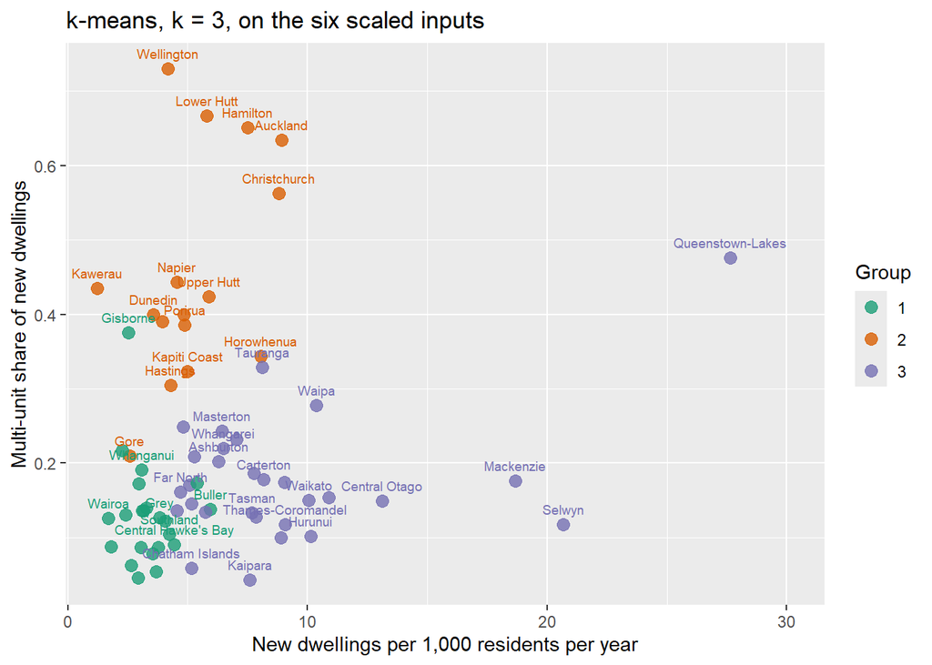

```r
cluster_plot(xy, group3, "k-means, k = 3, on the six scaled inputs") +
  labs(x = "New dwellings per 1,000 residents per year",
       y = "Multi-unit share of new dwellings")
```

Group 1 (22 districts) sits bottom-left: low building rates, mostly stand-alone houses. Group 2 (16) is the upper part of the cloud, the districts with the most multi-unit housing. Group 3 (29) is the rest: the middle of the cloud and its right-hand side, where the fast builders are. The colours overlap where the cloud is thickest because the picture shows two of six inputs; the other four also had a say.

## 3.4 Choosing k

The quantity $k$-means minimises cannot choose $k$ for us. More clusters always fit tighter, so the share of variation explained, $1 - \frac{\text{tot.withinss}}{\text{totss}}$, rises with every extra cluster:

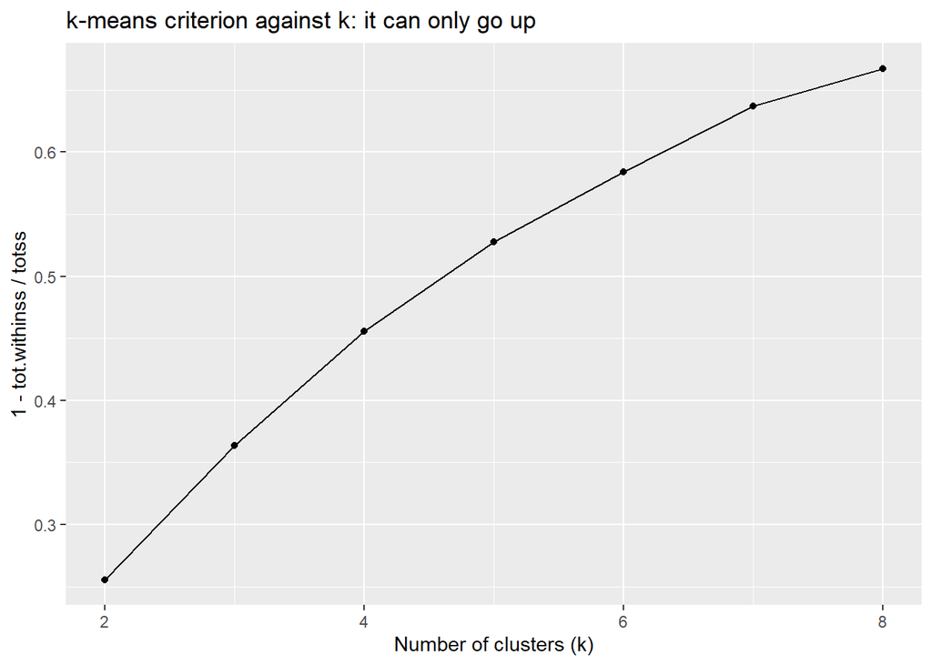

```r
kmeans.criterion <- rep(0, 7)
for (k in 2:8) {
  set.seed(462)
  clus <- kmeans(scaled_dat, k, nstart = 50)
  kmeans.criterion[k - 1] <- 1 - clus$tot.withinss / clus$totss
}

plot_dat <- data.frame(k = 2:8, kmeans_criterion = kmeans.criterion)

ggplot(plot_dat, aes(x = k, y = kmeans_criterion)) +
  geom_line() +
  geom_point() +
  labs(title = "k-means criterion against k: it can only go up",
       x = "Number of clusters (k)", y = "1 - tot.withinss / totss")
```

It climbs steadily from 0.26 at $k = 2$ to 0.67 at $k = 8$ with no bend in the curve to suggest a natural stopping point.

The silhouette coefficient is the course’s tool for this. For a district $x_j$ it compares **cohesion**, the mean distance to the other members of its own cluster, $a(x_j)$, with **separation**, the mean distance to the members of the nearest other cluster, $b(x_j)$:

$$s(x_j) = \frac{b(x_j) -
a(x_j)}{\max\{a(x_j),\, b(x_j)\}}$$

It runs from −1 to 1. Near 1, the district is far closer to its own cluster than to any other; near 0, it sits on a boundary; below 0, it would be better placed in the neighbouring cluster. The average over all districts, $S(C)$, scores the whole clustering.

```r
dist_matrix <- dist(scaled_dat)

sil <- silhouette(k.clus$cluster, dist_matrix)
summary(sil)$avg.width
```

```
## [1] 0.2269404
```

For $k = 3$ the average is 0.23. The same calculation for $k$ from 2 to 8:

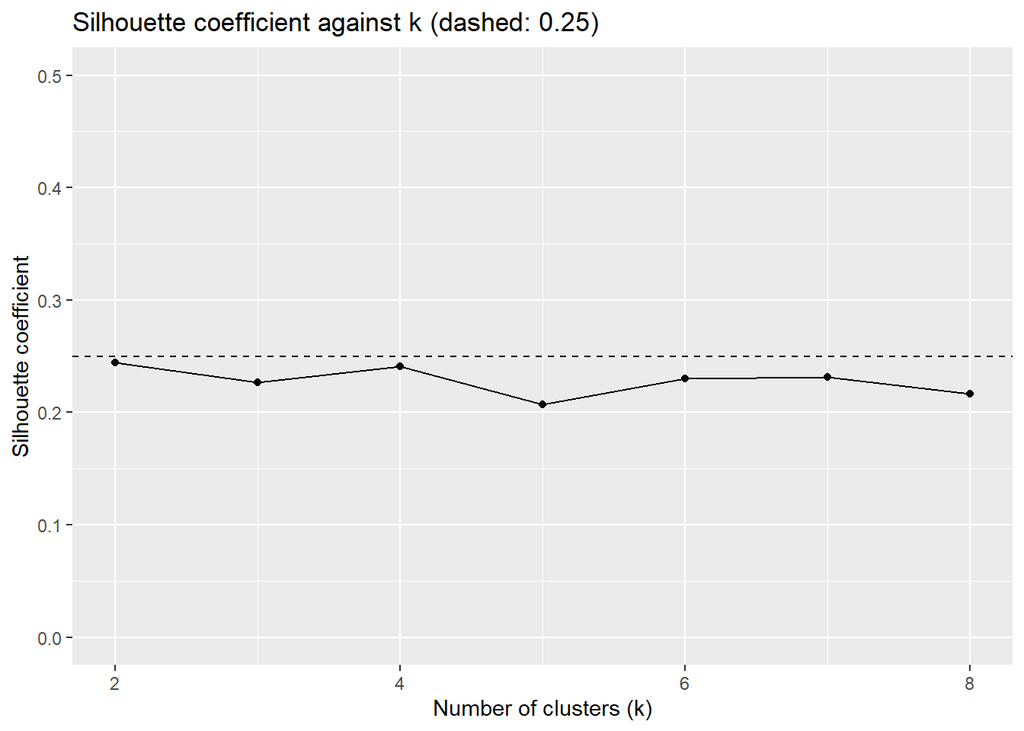

```r
sils <- rep(0, 7)
sizes <- rep("", 7)
for (k in 2:8) {
  set.seed(462)
  clus <- kmeans(scaled_dat, k, nstart = 50)
  sils[k - 1]  <- summary(silhouette(clus$cluster, dist_matrix))$avg.width
  sizes[k - 1] <- paste(sort(clus$size, decreasing = TRUE), collapse = " / ")
}

plot_dat <- data.frame(k = 2:8, sils = sils, kmeans_criterion = kmeans.criterion, sizes = sizes)

ggplot(plot_dat, aes(x = k, y = sils)) +
  geom_line() +
  geom_point() +
  geom_hline(yintercept = 0.25, linetype = "dashed") +
  ylim(0, 0.5) +
  labs(title = "Silhouette coefficient against k (dashed: 0.25)",
       x = "Number of clusters (k)", y = "Silhouette coefficient")
```

```r
plot_dat %>%
  mutate(across(c(sils, kmeans_criterion), ~ round(.x, 3))) %>%
  knitr::kable(col.names = c("k", "Silhouette", "1 - W/T", "Cluster sizes"),
               caption = "k-means for k = 2 to 8 on the six scaled inputs")
```

k-means for k = 2 to 8 on the six scaled inputs

| k | Silhouette | 1 - W/T | Cluster sizes |
| --- | --- | --- | --- |
| 2 | 0.244 | 0.256 | 39 / 28 |
| 3 | 0.227 | 0.364 | 29 / 22 / 16 |
| 4 | 0.241 | 0.456 | 28 / 24 / 12 / 3 |
| 5 | 0.207 | 0.528 | 21 / 18 / 17 / 8 / 3 |
| 6 | 0.230 | 0.584 | 21 / 19 / 11 / 7 / 6 / 3 |
| 7 | 0.232 | 0.637 | 19 / 16 / 15 / 7 / 6 / 3 / 1 |
| 8 | 0.217 | 0.667 | 19 / 17 / 8 / 7 / 6 / 6 / 3 / 1 |

*Which k is best?* The highest silhouette is at $k = 2$ (0.244), with $k = 4$ (0.241) just behind it and $k = 3$ at 0.227, and nothing from 2 to 8 falls outside 0.21–0.24. The lab’s flea-beetle data peaked sharply at the true number of species; this curve is flat. Two things follow.

First, the level matters more than the peak. Kaufman and Rousseeuw (1990), whose book set out how to read the coefficient, take the best average over all $k$ and call 0.25 or less “no substantial structure”, and 0.26–0.50 a weak structure that could be artificial. The best value here is 0.244. The districts are a continuum, as the scatter plot in section 2.3 suggested, and any $k$ is a convenient way of dividing it up, not a count of market types that exist in the data.

Second, since the silhouette does not separate 2, 3 and 4, the choice between them is ours to make and to justify. We carry $k = 3$ forward as the working description — it is the smallest number that separates *how much* a district builds from *what* it builds, and it is what the group pitched — and we look at $k = 2$ and $k = 4$ beside it below so the reader can see what the choice does.

## 3.5 How well each district fits

The average hides a lot. The silhouette of each district shows which ones belong firmly to their group and which sit on a boundary.

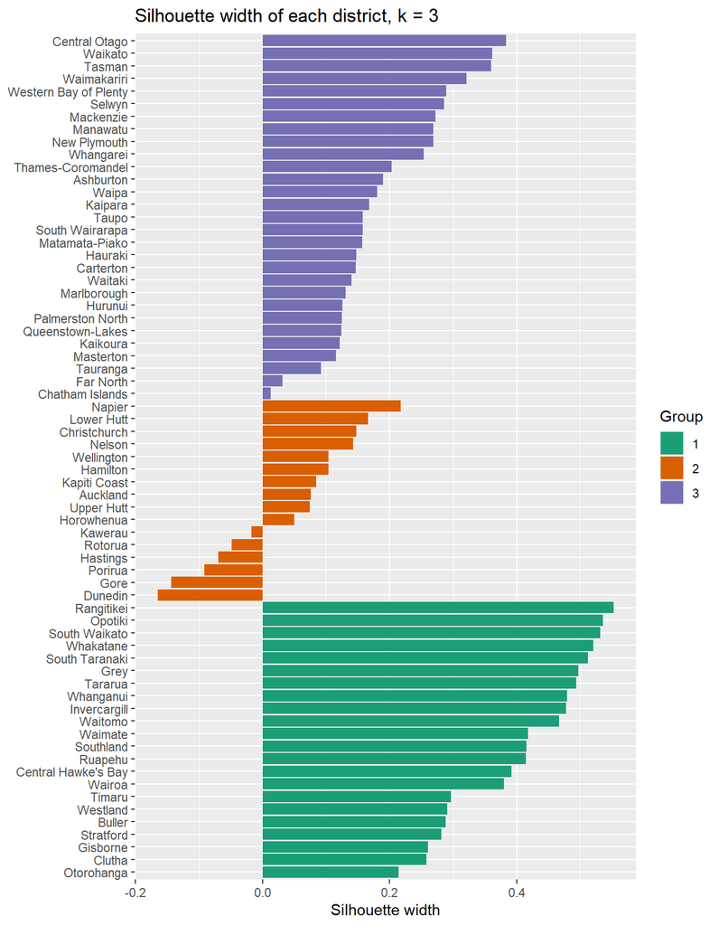

```r
sil_tbl <- tibble(district = rownames(scaled_dat),
                  group    = factor(group3),
                  width    = sil[, "sil_width"])

sil_tbl %>%
  arrange(group, width) %>%
  mutate(district = factor(district, levels = district)) %>%
  ggplot(aes(x = district, y = width, fill = group)) +
  geom_col() +
  coord_flip() +
  scale_fill_manual(values = group_colours) +
  labs(title = "Silhouette width of each district, k = 3",
       x = NULL, y = "Silhouette width", fill = "Group")
```

```r
sil_tbl %>%
  group_by(group) %>%
  summarise(districts = n(),
            mean_width = round(mean(width), 3),
            below_0.1 = sum(width < 0.1),
            negative = paste(district[width < 0], collapse = ", ")) %>%
  knitr::kable(caption = "Silhouette by group, k = 3")
```

Silhouette by group, k = 3

| group | districts | mean_width | below_0.1 | negative |
| --- | --- | --- | --- | --- |
| 1 | 22 | 0.408 | 0 |  |
| 2 | 16 | 0.040 | 10 | Dunedin, Gore, Hastings, Kawerau, Porirua, Rotorua |
| 3 | 29 | 0.193 | 3 |  |

Group 1 is the only one that holds together: its average width is 0.41 and every one of its 22 districts is above 0.2. Group 3 averages 0.19. Group 2 averages 0.04: ten of its sixteen districts are below 0.1 and six are negative — Dunedin, Gore, Hastings, Kawerau, Porirua and Rotorua are on average closer to the members of another group than to their own. For that group $k$-means has drawn a line through the cloud; it has not found a cluster.

## 3.6 Describing the groups

A cluster is only useful if it can be described. The centres, in the original units:

```r
profile$group3 <- factor(group3)

# mean of every input within each group, with the number of districts in it
group_means <- function(label) {
  dat %>%
    mutate(group = label) %>%
    group_by(group) %>%
    summarise(districts = n(), across(all_of(inputs), mean))
}

group_means(group3) %>%
  mutate(across(c(multi_share, retire_share, growth, alt_share), ~ round(.x, 3)),
         house_m2 = round(house_m2), per1000 = round(per1000, 1)) %>%
  knitr::kable(caption = "Group means, k = 3 (groups numbered by building rate, lowest first)")
```

Group means, k = 3 (groups numbered by building rate, lowest first)

| group | districts | multi_share | retire_share | house_m2 | per1000 | growth | alt_share |
| --- | --- | --- | --- | --- | --- | --- | --- |
| 1 | 22 | 0.131 | 0.009 | 174 | 3.4 | 0.321 | 0.228 |
| 2 | 16 | 0.456 | 0.091 | 180 | 5.2 | 0.206 | 0.182 |
| 3 | 29 | 0.178 | 0.062 | 190 | 9.0 | -0.016 | 0.127 |

```r
profile %>%
  group_by(group3) %>%
  summarise(districts = n(), members = paste(sort(district), collapse = ", ")) %>%
  knitr::kable(caption = "Members of each group, k = 3")
```

Members of each group, k = 3

| group3 | districts | members |
| --- | --- | --- |
| 1 | 22 | Buller, Central Hawke’s Bay, Clutha, Gisborne, Grey, Invercargill, Opotiki, Otorohanga, Rangitikei, Ruapehu, South Taranaki, South Waikato, Southland, Stratford, Tararua, Timaru, Waimate, Wairoa, Wait… |
| 2 | 16 | Auckland, Christchurch, Dunedin, Gore, Hamilton, Hastings, Horowhenua, Kapiti Coast, Kawerau, Lower Hutt, Napier, Nelson, Porirua, Rotorua, Upper Hutt, Wellington |
| 3 | 29 | Ashburton, Carterton, Central Otago, Chatham Islands, Far North, Hauraki, Hurunui, Kaikoura, Kaipara, Mackenzie, Manawatu, Marlborough, Masterton, Matamata-Piako, New Plymouth, Palmerston North, Queen… |

In words:

- **Group 1 — slow provincial (22 districts).** 3.4 new dwellings per 1,000 residents a year, two-thirds of the median district’s 5.1. Nearly a quarter of residential spending (23%) goes on existing homes, the houses that are built are the smallest (174 m²), and almost all new housing is stand-alone (13% multi-unit, under 1% retirement units). Building did pick up within the window — about 38% more dwellings a year in 2021–2025 than in 2016–2020 — from a low base. Whanganui, Invercargill, Timaru, Gisborne, Southland, South Taranaki and the three West Coast districts are typical.
- **Group 2 — dense urban (16).** The group with a different *form* of housing: 46% multi-unit and 9% retirement-village units. It holds the main centres (Auckland, Christchurch, Wellington, Hamilton, Dunedin), the Hutt Valley and Porirua, and Napier, Hastings and Nelson. Its building rate is ordinary, 5.2 per 1,000. Gore, Kawerau and Rotorua are also placed here and are among the members that fit worst (section 3.5).
- **Group 3 — building for growth (29).** 9.0 dwellings per 1,000 a year, more than two and a half times group 1, in the biggest houses (190 m²) and with the smallest alteration share (13%). Queenstown-Lakes, Selwyn, Waimakariri, Central Otago, Tasman, Western Bay of Plenty and Tauranga are here, along with provincial centres that are growing steadily (Whangarei, New Plymouth, Palmerston North). Building within the window was flat.

## 3.7 Two and four clusters beside it

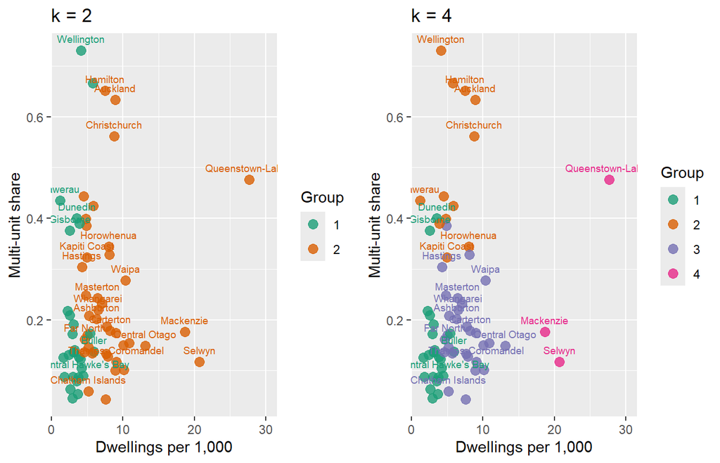

```r
set.seed(462)
k.clus2 <- kmeans(scaled_dat, 2, nstart = 50)
set.seed(462)
k.clus4 <- kmeans(scaled_dat, 4, nstart = 50)

group2 <- relabel(k.clus2$cluster, dat$per1000)
group4 <- relabel(k.clus4$cluster, dat$per1000)

p2 <- cluster_plot(xy, group2, "k = 2") + labs(x = "Dwellings per 1,000", y = "Multi-unit share")
p4 <- cluster_plot(xy, group4, "k = 4") + labs(x = "Dwellings per 1,000", y = "Multi-unit share")
grid.arrange(p2, p4, ncol = 2)
```

```r
# where the k = 3 groups go when k is 2 or 4
table(k3 = group3, k2 = group2)
```

```
##    k2
## k3   1  2
##   1 22  0
##   2  6 10
##   3  0 29
```

```r
table(k3 = group3, k4 = group4)
```

```
##    k4
## k3   1  2  3  4
##   1 22  0  0  0
##   2  2 12  2  0
##   3  0  0 26  3
```

```r
group_means(group4) %>%
  mutate(across(c(multi_share, retire_share, growth, alt_share), ~ round(.x, 3)),
         house_m2 = round(house_m2), per1000 = round(per1000, 1)) %>%
  knitr::kable(caption = "Group means, k = 4")
```

Group means, k = 4

| group | districts | multi_share | retire_share | house_m2 | per1000 | growth | alt_share |
| --- | --- | --- | --- | --- | --- | --- | --- |
| 1 | 24 | 0.146 | 0.013 | 176 | 3.3 | 0.313 | 0.228 |
| 2 | 12 | 0.500 | 0.099 | 176 | 5.7 | 0.250 | 0.179 |
| 3 | 28 | 0.181 | 0.068 | 189 | 7.3 | -0.024 | 0.135 |
| 4 | 3 | 0.256 | 0.026 | 199 | 22.3 | 0.021 | 0.080 |

```r
# the dense urban districts that join the slow group when k is 2, and when k is 4
cat("k = 2:", paste(rownames(dat)[group3 == 2 & group2 == 1], collapse = ", "), "\n")
```

```
## k = 2: Dunedin, Gore, Kawerau, Lower Hutt, Rotorua, Wellington
```

```r
cat("k = 4:", paste(rownames(dat)[group3 == 2 & group4 == 1], collapse = ", "), "\n")
```

```
## k = 4: Dunedin, Gore
```

```r
# the fourth group at k = 4
cat("Group 4 at k = 4:", paste(rownames(dat)[group4 == 4], collapse = ", "), "\n")
```

```
## Group 4 at k = 4: Mackenzie, Queenstown-Lakes, Selwyn
```

The slow provincial group is the stable part: all 22 of its districts stay together at $k = 2$ and at $k = 4$. At $k = 2$ they are joined by six of the dense urban group (Dunedin, Gore, Kawerau, Lower Hutt, Rotorua and Wellington City) to make a cluster of 28, and the other 39 districts are simply everything else. At $k = 4$ they are joined by two (Dunedin and Gore). What changes with $k$ is how the remaining two-thirds of the country is divided: at $k = 4$ the three fastest builders — Mackenzie, Queenstown-Lakes and Selwyn, at 22 dwellings per 1,000 — split off on their own, a dense urban group of 12 (50% multi-unit) is left, and a broad middle of 28 takes the rest.

# 4 Hierarchical clustering

Hierarchical clustering does not need $k$ in advance. It starts with every district as its own cluster and repeatedly merges the two closest clusters until one remains, recording the order of merges as a tree. What “closest” means for two clusters is the linkage, and Module 7 covers three. All three use the same distance matrix as the silhouette above.

## 4.1 Complete linkage

The distance between two clusters is the distance between their two *furthest* members:
$$d(C_k, C_l) =
\max_{i,j}\left\{\lVert x_i - x_j\rVert : C(i) = k,\ C(j) =
l\right\}$$

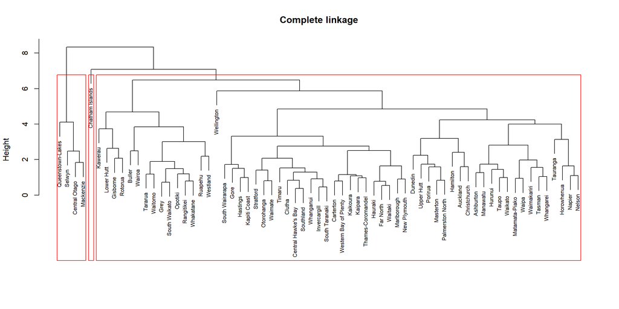

```r
hc.complete <- hclust(dist_matrix, method = "complete")

plot(hc.complete, main = "Complete linkage", xlab = "", sub = "", cex = 0.7)
rect.hclust(hc.complete, k = 3, border = "red")
```

```r
# the members of every cluster with six districts or fewer
small_clusters <- function(cut) {
  small <- names(which(table(cut) <= 6))
  if (length(small) == 0) return("none")
  paste(sapply(small, function(c) paste(names(cut)[cut == c], collapse = ", ")), collapse = " | ")
}

table(cutree(hc.complete, 3))
```

```
##
##  1  2  3
## 62  4  1
```

```r
small_clusters(cutree(hc.complete, 3))
```

```
## [1] "Central Otago, Mackenzie, Queenstown-Lakes, Selwyn | Chatham Islands"
```

Read the tree from the top. The first cut does not divide the country into types: it separates Queenstown-Lakes, Selwyn, Central Otago and Mackenzie from everyone else, and the second removes the Chatham Islands. Cut into three, complete linkage gives 62 districts, 4 and 1.

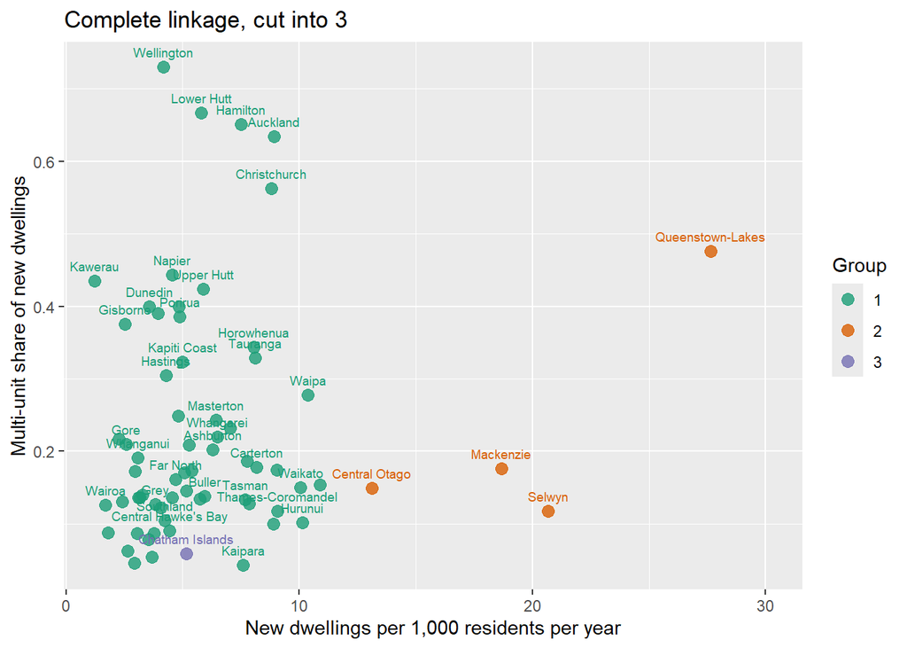

```r
cluster_plot(xy, cutree(hc.complete, 3), "Complete linkage, cut into 3") +
  labs(x = "New dwellings per 1,000 residents per year",
       y = "Multi-unit share of new dwellings")
```

## 4.2 Single linkage

The distance between two clusters is the distance between their two *closest* members:
$$d(C_k, C_l) =
\min_{i,j}\left\{\lVert x_i - x_j\rVert : C(i) = k,\ C(j) =
l\right\}$$

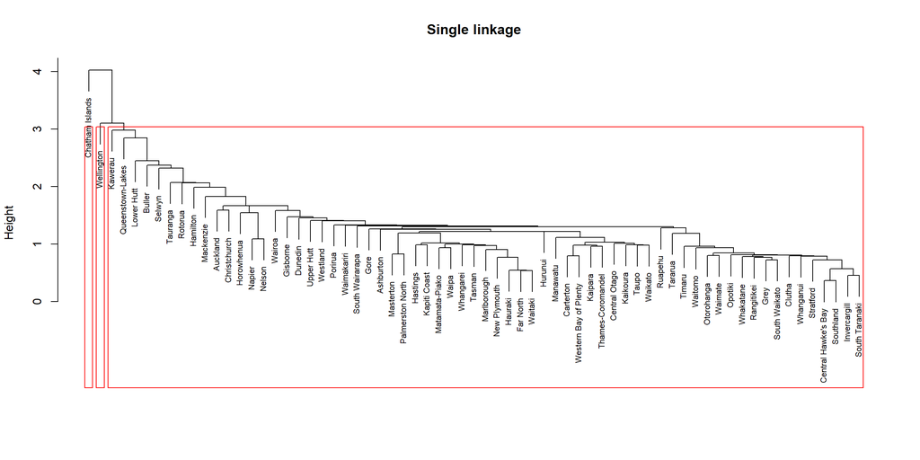

```r
hc.single <- hclust(dist_matrix, method = "single")

plot(hc.single, main = "Single linkage", xlab = "", sub = "", cex = 0.7)
rect.hclust(hc.single, k = 3, border = "red")
```

```r
table(cutree(hc.single, 3))
```

```
##
##  1  2  3
## 65  1  1
```

```r
small_clusters(cutree(hc.single, 3))
```

```
## [1] "Chatham Islands | Wellington"
```

Single linkage shows its chaining habit: districts join the main body one at a time, each because it is near *some* member of it, and the tree is a staircase. Cut into three it gives 65, 1 and 1 — the Chatham Islands and Wellington City on their own.

## 4.3 Group average linkage

The distance between two clusters is the average distance over every pair with one member in each:
$$d(C_k, C_l) =
\frac{\sum_{C(i) = k}\sum_{C(j) = l}\lVert x_i - x_j\rVert}{N_k
N_l}$$

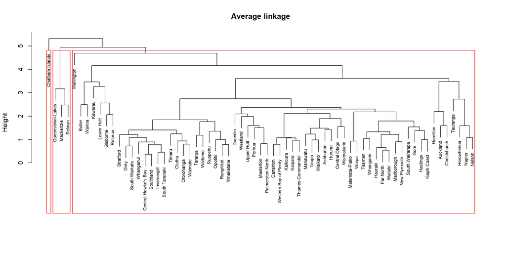

```r
hc.average <- hclust(dist_matrix, method = "average")

plot(hc.average, main = "Average linkage", xlab = "", sub = "", cex = 0.7)
rect.hclust(hc.average, k = 3, border = "red")
```

```r
table(cutree(hc.average, 3))
```

```
##
##  1  2  3
## 63  1  3
```

```r
small_clusters(cutree(hc.average, 3))
```

```
## [1] "Chatham Islands | Mackenzie, Queenstown-Lakes, Selwyn"
```

Average linkage sits between the other two: 63 districts, a fast-building trio, and the Chatham Islands.

## 4.4 What the three trees have in common

```r
# cluster sizes and silhouette for each linkage, cut into 2 to 5
linkage_tbl <- map_dfr(c("complete", "single", "average"), function(m) {
  hc <- hclust(dist_matrix, method = m)
  map_dfr(2:5, function(k) {
    cut <- cutree(hc, k)
    tibble(linkage = m, k = k,
           sizes = paste(sort(table(cut), decreasing = TRUE), collapse = " / "),
           silhouette = round(summary(silhouette(cut, dist_matrix))$avg.width, 3),
           `clusters of six or fewer` = small_clusters(cut))
  })
})

linkage_tbl %>%
  knitr::kable(caption = "Hierarchical clustering: cluster sizes and silhouette by linkage and number of clusters")
```

Hierarchical clustering: cluster sizes and silhouette by linkage and number of clusters

| linkage | k | sizes | silhouette | clusters of six or fewer |
| --- | --- | --- | --- | --- |
| complete | 2 | 63 / 4 | 0.318 | Central Otago, Mackenzie, Queenstown-Lakes, Selwyn |
| complete | 3 | 62 / 4 / 1 | 0.314 | Central Otago, Mackenzie, Queenstown-Lakes, Selwyn \| Chatham Islands |
| complete | 4 | 47 / 15 / 4 / 1 | 0.234 | Central Otago, Mackenzie, Queenstown-Lakes, Selwyn \| Chatham Islands |
| complete | 5 | 46 / 15 / 4 / 1 / 1 | 0.237 | Central Otago, Mackenzie, Queenstown-Lakes, Selwyn \| Chatham Islands \| Wellington |
| single | 2 | 66 / 1 | 0.401 | Chatham Islands |
| single | 3 | 65 / 1 / 1 | 0.321 | Chatham Islands \| Wellington |
| single | 4 | 64 / 1 / 1 / 1 | 0.271 | Chatham Islands \| Kawerau \| Wellington |
| single | 5 | 63 / 1 / 1 / 1 / 1 | 0.259 | Chatham Islands \| Kawerau \| Queenstown-Lakes \| Wellington |
| average | 2 | 66 / 1 | 0.401 | Chatham Islands |
| average | 3 | 63 / 3 / 1 | 0.359 | Chatham Islands \| Mackenzie, Queenstown-Lakes, Selwyn |
| average | 4 | 62 / 3 / 1 / 1 | 0.310 | Chatham Islands \| Mackenzie, Queenstown-Lakes, Selwyn \| Wellington |
| average | 5 | 56 / 6 / 3 / 1 / 1 | 0.283 | Buller, Gisborne, Kawerau, Lower Hutt, Rotorua, Wairoa \| Chatham Islands \| Mackenzie, Queenstown-Lakes, Selwyn \| Wellington |

Not one of the twelve cuts produces balanced groups. Every linkage spends its first cuts removing single districts or a handful of fast builders from one large body, and only complete linkage, at four clusters, begins to divide that body (47 and 15). The silhouettes look better than $k$-means’ — 0.31 to 0.40 at two and three clusters — but that is a property of the measure, not a success: a far-away singleton scores well on separation, and the 60-odd districts left behind are judged only against it.

So the trees answer a different question from the one we asked. They do not say what kinds of market there are; they say which districts are unlike all the others.

## 4.5 The outliers

The same thing can be read straight off the scaled data: how far is each district from the average district, in standard deviations across the six inputs?

```r
centre_dist <- sqrt(rowSums(scaled_dat^2))

outliers <- names(sort(centre_dist, decreasing = TRUE))[1:8]

cbind(distance = centre_dist[outliers], scaled_dat[outliers, ]) %>%
  round(2) %>%
  knitr::kable(caption = "The eight districts furthest from the average district (inputs in standard deviations)")
```

The eight districts furthest from the average district (inputs in standard deviations)

|  | distance | multi_share | retire_share | house_m2 | per1000 | growth | alt_share |
| --- | --- | --- | --- | --- | --- | --- | --- |
| Queenstown-Lakes | 5.44 | 1.52 | -0.19 | 1.34 | 4.85 | 0.10 | -1.42 |
| Chatham Islands | 4.76 | -1.05 | -1.02 | -2.94 | -0.25 | -3.22 | -1.18 |
| Wellington | 4.15 | 3.08 | -0.58 | 0.15 | -0.48 | -1.74 | 2.04 |
| Kawerau | 4.06 | 1.26 | 1.34 | -2.54 | -1.14 | 0.03 | 2.31 |
| Selwyn | 4.03 | -0.69 | -0.30 | 0.79 | 3.27 | 0.27 | -2.07 |
| Wairoa | 4.01 | -0.63 | -1.02 | -2.33 | -1.04 | 1.79 | 2.23 |
| Buller | 3.74 | -0.56 | -1.02 | -2.78 | -0.07 | 2.22 | 0.01 |
| Lower Hutt | 3.59 | 2.69 | 0.40 | -1.86 | -0.11 | 1.32 | 0.52 |

Queenstown-Lakes is furthest, 4.9 standard deviations above the mean building rate. The Chatham Islands follow, on small houses and a growth figure that rests on 34 dwellings. Wellington City is the densest district (3.1 standard deviations above the mean) and has one of the highest alteration shares; Kawerau and Wairoa have the two lowest building rates and the two highest alteration shares; Selwyn is the fast-building pattern without the density. These are the names the three trees pick off first.

# 5 Evaluate performance

There is no test set in clustering and no right answer to score against. The questions that can be asked are whether the result depends on the method, on chance, or on the years chosen, and whether the groups are useful for anything outside the clustering itself.

## 5.1 Do the two methods agree?

```r
table(kmeans = group3, complete = cutree(hc.complete, 3))
```

```
##       complete
## kmeans  1  2  3
##      1 22  0  0
##      2 16  0  0
##      3 24  4  1
```

At three clusters they describe different things: $k$-means divides the cloud into 22, 16 and 29, and complete linkage puts 62 of the 67 districts in one cluster. Cutting the complete-linkage tree one step further down gives it a chance to divide the main body:

```r
table(kmeans = group3, complete = cutree(hc.complete, 4))
```

```
##       complete
## kmeans  1  2  3  4
##      1 10 12  0  0
##      2 13  3  0  0
##      3 24  0  4  1
```

At four clusters the tree does find the core of the slow provincial group: its new cluster of 15 holds 12 of $k$-means’ 22 slow districts and only 3 others. The remaining 47 mix all three $k$-means groups. So the two methods agree where the $k$-means answer was already firmest — the slow provincial districts, and the fastest builders as a thing apart — and neither finds a line between the dense urban districts and the growth districts.

## 5.2 Does the result depend on chance?

Section 3.2 answered this for the starting point: a single start gave fourteen different answers in thirty runs, fifty starts gave one. The reported clustering is reproducible, but only because of `nstart`.

## 5.3 Does it depend on the ten years chosen?

A market type ought to be a lasting feature of a district. We rebuild the profile for a longer window (2011–2025) and a shorter, more recent one (2021–2025), cluster each with $k = 3$ in exactly the same way, and count how many districts stay in the same group as in the 2016–2025 result.

```r
# share of districts that keep their group, after matching the labels of b to a
agreement <- function(a, b) {
  tab <- table(a, b)
  orders <- list(c(1, 2, 3), c(1, 3, 2), c(2, 1, 3), c(2, 3, 1), c(3, 1, 2), c(3, 2, 1))
  max(sapply(orders, function(o) sum(tab[cbind(1:3, o)]))) / length(a)
}

# k-means with k = 3 on the profile of another window
cluster_window <- function(first_year, last_year) {
  p <- build_profile(first_year, last_year)
  d <- as.data.frame(p[, inputs])
  set.seed(462)
  relabel(kmeans(scale(d), 3, nstart = 50)$cluster, d$per1000)
}

group3_long   <- cluster_window(2011, 2025)
group3_recent <- cluster_window(2021, 2025)

tibble(window = c("2011-2025 (15 years)", "2021-2025 (5 years)"),
       share = c(agreement(group3, group3_long), agreement(group3, group3_recent))) %>%
  mutate(same_group = round(share * 67), share = round(share, 3)) %>%
  dplyr::select(window, same_group, share) %>%
  knitr::kable(caption = "Districts in the same group as the 2016-2025 clustering (of 67)")
```

Districts in the same group as the 2016-2025 clustering (of 67)

| window | same_group | share |
| --- | --- | --- |
| 2011-2025 (15 years) | 60 | 0.896 |
| 2021-2025 (5 years) | 52 | 0.776 |

```r
table(`2016-2025` = group3, `2011-2025` = group3_long)
```

```
##          2011-2025
## 2016-2025  1  2  3
##         1 21  1  0
##         2  0 16  0
##         3  3  3 23
```

```r
table(`2016-2025` = group3, `2021-2025` = group3_recent)
```

```
##          2021-2025
## 2016-2025  1  2  3
##         1 22  0  0
##         2  1 13  2
##         3  6  6 17
```

```r
# which districts change group when only the last five years are used
profile %>%
  mutate(recent = group3_recent) %>%
  dplyr::filter(as.integer(group3) != recent) %>%
  transmute(district, `group 2016-2025` = group3, `group 2021-2025` = recent) %>%
  arrange(`group 2016-2025`, `group 2021-2025`) %>%
  knitr::kable(caption = "Districts whose group depends on the window")
```

Districts whose group depends on the window

| district | group 2016-2025 | group 2021-2025 |
| --- | --- | --- |
| Gore | 2 | 1 |
| Auckland | 2 | 3 |
| Christchurch | 2 | 3 |
| Carterton | 3 | 1 |
| Chatham Islands | 3 | 1 |
| Far North | 3 | 1 |
| Kaipara | 3 | 1 |
| Thames-Coromandel | 3 | 1 |
| Waitaki | 3 | 1 |
| Hauraki | 3 | 2 |
| Marlborough | 3 | 2 |
| New Plymouth | 3 | 2 |
| South Wairarapa | 3 | 2 |
| Tauranga | 3 | 2 |
| Whangarei | 3 | 2 |

With the longer window 60 of the 67 districts (90%) keep their group; with the last five years alone, 52 (78%). The two cross-tables show where the movement is. The slow provincial group barely moves: 21 of its 22 districts are in the slow group of the 2011–2025 clustering, and all 22 are in the slow group of the 2021–2025 one. The 15 districts that change group in the recent window all come from the other two. Auckland and Christchurch leave the dense urban group for the growth group; six districts leave the growth group for the slow one (Carterton, the Chatham Islands, Far North, Kaipara, Thames-Coromandel and Waitaki) and six more for the dense group (Hauraki, Marlborough, New Plymouth, South Wairarapa, Tauranga and Whangarei). Where the line falls between “dense urban” and “building for growth” depends on which years are looked at.

The same check, leaving out four of the districts the trees set aside (Queenstown-Lakes, Mackenzie, Selwyn and the Chatham Islands), asks whether the outliers are steering the result:

```r
keep <- !(rownames(dat) %in% c("Queenstown-Lakes", "Mackenzie", "Selwyn", "Chatham Islands"))

set.seed(462)
k.clus_trim <- kmeans(scale(dat[keep, ]), 3, nstart = 50)
group3_trim <- relabel(k.clus_trim$cluster, dat$per1000[keep])

table(`all 67` = group3[keep], `without the four` = group3_trim)
```

```
##       without the four
## all 67  1  2  3
##      1 19  3  0
##      2  3  3 10
##      3  0  0 25
```

```r
cat("Districts in the same group with the four outliers removed:",
    round(agreement(group3[keep], group3_trim) * sum(keep)), "of", sum(keep), "\n")
```

```
## Districts in the same group with the four outliers removed: 47 of 63
```

```r
cat("Silhouette without them:",
    round(summary(silhouette(k.clus_trim$cluster, dist(scale(dat[keep, ]))))$avg.width, 3), "\n")
```

```
## Silhouette without them: 0.259
```

Removing the four outliers changes the group of 16 of the remaining 63 districts. The slow provincial group keeps 19 of its 22 and the growth group stays whole, but the dense urban group breaks up: 10 of its 16 districts join the growth group. The silhouette without the outliers is 0.26, right on the line between no structure and weak structure. The pattern is the same as with the window: one group that holds, and a boundary between the other two that moves whenever something is changed.

## 5.4 Do the groups differ in cost?

This is the link back to RQ1, which found that location explains more of the cost of a new house than any driver we could measure. If the groups describe real kinds of market, they should carry some of that location effect. `rel_cost` is the district’s real cost per m² of new houses over 2016–2025 relative to the country’s, on a log scale, and it was *not* used to form the groups.

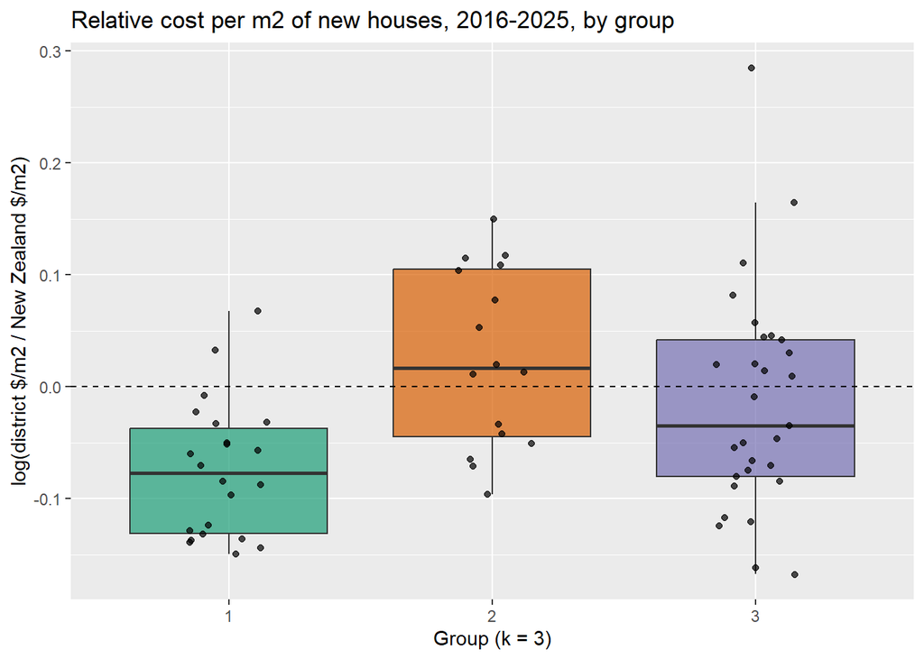

```r
# geom_jitter() draws random numbers, so fix the seed to get the same picture each knit
set.seed(462)
ggplot(profile, aes(x = group3, y = rel_cost, fill = group3)) +
  geom_boxplot(alpha = 0.7, outlier.shape = NA) +
  geom_jitter(width = 0.15, size = 1.5, alpha = 0.7) +
  geom_hline(yintercept = 0, linetype = "dashed") +
  scale_fill_manual(values = group_colours) +
  labs(title = "Relative cost per m2 of new houses, 2016-2025, by group",
       x = "Group (k = 3)", y = "log(district $/m2 / New Zealand $/m2)") +
  theme(legend.position = "none")
```

```r
cost.fit <- lm(rel_cost ~ group3, data = profile)
summary(cost.fit)
```

```
##
## Call:
## lm(formula = rel_cost ~ group3, data = profile)
##
## Residuals:
##       Min        1Q    Median        3Q       Max
## -0.152968 -0.061925 -0.009496  0.052084  0.299836
##
## Coefficients:
##             Estimate Std. Error t value Pr(>|t|)
## (Intercept) -0.07479    0.01781  -4.200 8.43e-05 ***
## group32      0.10050    0.02744   3.662 0.000509 ***
## group33      0.06008    0.02361   2.544 0.013379 *
## ---
## Signif. codes:  0 '***' 0.001 '**' 0.01 '*' 0.05 '.' 0.1 ' ' 1
##
## Residual standard error: 0.08352 on 64 degrees of freedom
## Multiple R-squared:  0.1811, Adjusted R-squared:  0.1555
## F-statistic: 7.077 on 2 and 64 DF,  p-value: 0.001672
```

```r
# the same model with group 2 as the baseline, to compare groups 2 and 3 directly
round(summary(lm(rel_cost ~ relevel(group3, ref = "2"), data = profile))$coefficients, 4)
```

```
##                             Estimate Std. Error t value Pr(>|t|)
## (Intercept)                   0.0257     0.0209  1.2312   0.2227
## relevel(group3, ref = "2")1  -0.1005     0.0274 -3.6621   0.0005
## relevel(group3, ref = "2")3  -0.0404     0.0260 -1.5539   0.1251
```

```r
# how much of the cost differences between districts each grouping accounts for
r2_row <- function(label, fit) {
  s <- summary(fit)
  tibble(grouping = label, parameters = length(coef(fit)) - 1,
         R2 = round(s$r.squared, 3), adjusted_R2 = round(s$adj.r.squared, 3))
}

profile$group2 <- factor(group2)
profile$group4 <- factor(group4)

bind_rows(
  r2_row("k-means, 2 groups", lm(rel_cost ~ group2, data = profile)),
  r2_row("k-means, 3 groups", cost.fit),
  r2_row("k-means, 4 groups", lm(rel_cost ~ group4, data = profile)),
  r2_row("Region (17 regions)", lm(rel_cost ~ region, data = profile)),
  r2_row("3 groups + region", lm(rel_cost ~ group3 + region, data = profile))
) %>%
  knitr::kable(caption = "Share of between-district variation in relative cost explained")
```

Share of between-district variation in relative cost explained

| grouping | parameters | R2 | adjusted_R2 |
| --- | --- | --- | --- |
| k-means, 2 groups | 1 | 0.090 | 0.076 |
| k-means, 3 groups | 2 | 0.181 | 0.156 |
| k-means, 4 groups | 3 | 0.198 | 0.159 |
| Region (17 regions) | 16 | 0.413 | 0.225 |
| 3 groups + region | 18 | 0.456 | 0.252 |

The box plot and the regression say the same thing. The slow provincial districts sit clearly lower: their mean relative cost is −0.075, about 7% below the country as a whole. The dense urban group is 0.10 higher on the log scale, about 11% dearer than the slow group ($p < 0.001$), and the growth group 0.06 higher, about 6% ($p = 0.013$). The second regression tests the two upper groups against each other: the growth group is 0.04 below the dense urban group with a $p$-value of 0.13, a difference that could be chance. On cost there are two kinds of district, not three — the slow provincial ones, and everyone else.

Three groups built without any cost information account for 18% of the variation in cost between districts (16% adjusted). Region accounts for 41%, but spends 16 parameters on 67 districts to do it, and adjusted for that it is 23%. Putting both in the model lifts adjusted $R^2$ only to 0.25, so the groups and the regions are largely describing the same thing from two directions: where a district is, and how it builds.

## 5.5 With cost as an input

Niwesh’s clustering describes one of its groups as “denser and dearer”, which means cost is among his inputs. To compare like with like on Friday we add `rel_cost` as a seventh input and repeat the same steps.

```r
dat_cost <- as.data.frame(profile[, c(inputs, "rel_cost")])
rownames(dat_cost) <- profile$district
scaled_cost <- scale(dat_cost)
dist_cost <- dist(scaled_cost)

sils_cost <- rep(0, 7)
for (k in 2:8) {
  set.seed(462)
  clus <- kmeans(scaled_cost, k, nstart = 50)
  sils_cost[k - 1] <- summary(silhouette(clus$cluster, dist_cost))$avg.width
}

tibble(k = 2:8, `six inputs` = round(sils, 3), `six inputs + cost` = round(sils_cost, 3)) %>%
  knitr::kable(caption = "Silhouette by k, without and with cost as an input")
```

Silhouette by k, without and with cost as an input

| k | six inputs | six inputs + cost |
| --- | --- | --- |
| 2 | 0.244 | 0.216 |
| 3 | 0.227 | 0.205 |
| 4 | 0.241 | 0.186 |
| 5 | 0.207 | 0.197 |
| 6 | 0.230 | 0.196 |
| 7 | 0.232 | 0.196 |
| 8 | 0.217 | 0.210 |

Adding cost lowers the silhouette at every $k$, to 0.19–0.22. Cost is one more direction in which the districts are spread out; it does not sharpen the groups.

```r
set.seed(462)
k.clus_cost <- kmeans(scaled_cost, 3, nstart = 50)
group3_cost <- relabel(k.clus_cost$cluster, dat_cost$per1000)

table(`without cost` = group3, `with cost` = group3_cost)
```

```
##             with cost
## without cost  1  2  3
##            1 22  0  0
##            2  4 12  0
##            3  0  3 26
```

```r
cat("Districts in the same group with and without cost:",
    round(agreement(group3, group3_cost) * 67), "of 67\n")
```

```
## Districts in the same group with and without cost: 60 of 67
```

```r
cat("Districts that move:", paste(rownames(dat)[group3 != group3_cost], collapse = ", "), "\n")
```

```
## Districts that move: Dunedin, Gore, Kawerau, Queenstown-Lakes, Rotorua, South Wairarapa, Tauranga
```

60 of the 67 districts keep their group. Of the seven that move, Dunedin, Gore, Kawerau and Rotorua go from the dense urban group to the slow one — four of the six districts with a negative silhouette in section 3.5 — and Queenstown-Lakes, South Wairarapa and Tauranga go from the growth group to the dense one.

```r
dat_cost %>%
  mutate(group = group3_cost) %>%
  group_by(group) %>%
  summarise(districts = n(), across(everything(), mean)) %>%
  mutate(across(c(multi_share, retire_share, growth, alt_share, rel_cost), ~ round(.x, 3)),
         house_m2 = round(house_m2), per1000 = round(per1000, 1)) %>%
  knitr::kable(caption = "Group means with cost as a seventh input, k = 3")
```

Group means with cost as a seventh input, k = 3

| group | districts | multi_share | retire_share | house_m2 | per1000 | growth | alt_share | rel_cost |
| --- | --- | --- | --- | --- | --- | --- | --- | --- |
| 1 | 26 | 0.166 | 0.020 | 174 | 3.3 | 0.334 | 0.231 | -0.071 |
| 2 | 15 | 0.456 | 0.096 | 184 | 7.8 | 0.107 | 0.155 | 0.068 |
| 3 | 26 | 0.161 | 0.058 | 190 | 8.4 | -0.014 | 0.127 | -0.032 |

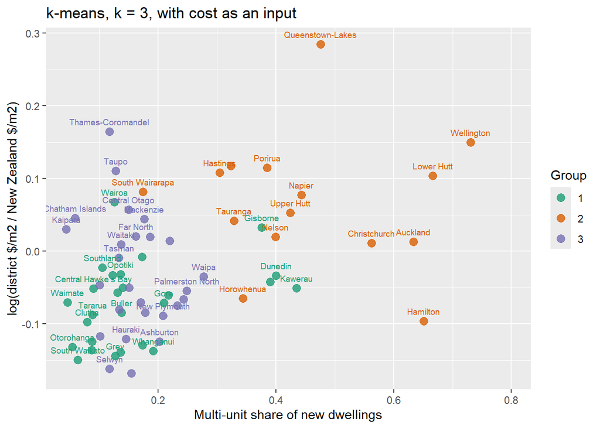

```r
cluster_plot(dat_cost[, c("multi_share", "rel_cost")], group3_cost,
             "k-means, k = 3, with cost as an input") +
  labs(x = "Multi-unit share of new dwellings",
       y = "log(district $/m2 / New Zealand $/m2)")
```

With cost as an input the second group is 15 districts that are 46% multi-unit and 7% above the national cost per m², now including Queenstown-Lakes: the “denser and dearer” cluster of Niwesh’s build. The slow group grows to 26 and is 7% below. The two builds are describing the same picture. The difference is that the headline version here keeps cost out, so that the comparison in section 5.4 means something.

## 5.6 Where this leaves RQ2

The answer has three parts, each pointing at the table or figure behind it.

New Zealand’s districts do not fall into natural market types. The silhouette coefficient is between 0.21 and 0.24 for every number of clusters from 2 to 8 (section 3.4), under the 0.25 that is read as no substantial structure, and the three hierarchical trees (section 4) spend their first cuts setting single districts aside instead of dividing the country. The six inputs carry two ideas — how much a district builds for its size, and what form the building takes — and the districts are spread along both without gaps.

Within that continuum one group is real and a few districts stand alone. The 22 slow provincial districts — 3.4 new dwellings per 1,000 residents a year, 23% of residential spending on existing homes, the smallest houses — have an average silhouette of 0.41 and largely stay together whatever is changed: all 22 at $k = 2$, 3 and 4 (section 3.7), 21 and 22 of them for a 15-year and a 5-year window, and 19 with the outliers removed (section 5.3). They are also the one part of the $k$-means answer that complete linkage finds for itself (section 5.1). At the other end, Queenstown-Lakes, Selwyn, Mackenzie and Central Otago are the first districts complete linkage separates and three of them form their own cluster at $k = 4$; the Chatham Islands and Wellington City are each unlike everything else. The districts in between can be divided into a dense urban group (16 districts, 46% multi-unit) and a building-for-growth group (29 districts, 9.0 dwellings per 1,000), and that is a useful way to talk about them. But the dense urban group has a silhouette of 0.04, 15 of the 67 districts change group when only the last five years are used, and 16 of 63 change when four outliers are removed. It is a convenient division, not a finding.

The groups carry information about cost even though cost was not used to form them (section 5.4). Slow provincial districts are about 7% cheaper per m² than the country as a whole; the other two groups are 6–11% dearer than the slow group and not distinguishable from each other. Three groups account for 18% of the differences in cost between districts, against 41% for region with eight times as many parameters. That connects the two research questions: RQ1 found that location matters more than any driver we could measure, and part of what “location” stands for is the kind of building market a district is.

For the poster, the defensible line is: *one clear type, a handful of districts unlike any other, and a continuum in between.* Three named groups are fine as labels for a non-technical audience as long as the silhouette is on the poster with them.

**Limitations.** There are 67 districts, so every group mean rests on a couple of dozen points and the smallest districts’ shares rest on a few buildings. The six inputs are our choice, and with silhouettes this low a different choice moves districts between groups: adding one input (cost) moved 7, and changing the window moved up to 15. Auckland is one district here, although it consented about 40% of the country’s new dwellings in these ten years. Consents record intentions to build, not completed buildings.

**Sources.** Stats NZ, *Building consents issued: August 2026* (CC BY 4.0), via the district-quarter table built in Niwesh’s Step 1 notebook. Kaufman, L., & Rousseeuw, P. J. (1990). *Finding groups in data: An introduction to cluster analysis*. Wiley — for the reading of the silhouette coefficient. Methods and code patterns follow STAT462 Lab Module 7 (clustering).

*End of document*